# Subscription Prediction

# Data Explanation

This dataset has been dowloaded from UCI Machine Learning Repository. “The data is related with direct marketing campaigns of a Portuguese banking institution. The marketing campaigns were based on phone calls. Often, more than one contact to the same client was required, in order to access if the product (bank term deposit) would be (‘yes’) or not (‘no’) subscribed.” (See https://archive.ics.uci.edu/ml/datasets/bank+marketing ). See also the `dataset_description.txt` and `attribute_info.txt` for explanation of the datasets and variables.

# Data Preparation

```r
# libraries
library(dplyr)
library(naniar)
library(visdat)
library(mice)
library(ggplot2)
library(corrplot)
library(e1071)
library(plotly)
library(ggmosaic)
```

```r
# read the data
data = read.csv("bank-additional/bank-additional-full.csv", sep = ";")
```

Take a look at the data:

```r
summary(data)
```

```
##       age                 job            marital
##  Min.   :17.00   admin.     :10422   divorced: 4612
##  1st Qu.:32.00   blue-collar: 9254   married :24928
##  Median :38.00   technician : 6743   single  :11568
##  Mean   :40.02   services   : 3969   unknown :   80
##  3rd Qu.:47.00   management : 2924
##  Max.   :98.00   retired    : 1720
##                  (Other)    : 6156
##                education        default         housing
##  university.degree  :12168   no     :32588   no     :18622
##  high.school        : 9515   unknown: 8597   unknown:  990
##  basic.9y           : 6045   yes    :    3   yes    :21576
##  professional.course: 5243
##  basic.4y           : 4176
##  basic.6y           : 2292
##  (Other)            : 1749
##       loan            contact          month       day_of_week
##  no     :33950   cellular :26144   may    :13769   fri:7827
##  unknown:  990   telephone:15044   jul    : 7174   mon:8514
##  yes    : 6248                     aug    : 6178   thu:8623
##                                    jun    : 5318   tue:8090
##                                    nov    : 4101   wed:8134
##                                    apr    : 2632
##                                    (Other): 2016
##     duration         campaign          pdays          previous
##  Min.   :   0.0   Min.   : 1.000   Min.   :  0.0   Min.   :0.000
##  1st Qu.: 102.0   1st Qu.: 1.000   1st Qu.:999.0   1st Qu.:0.000
##  Median : 180.0   Median : 2.000   Median :999.0   Median :0.000
##  Mean   : 258.3   Mean   : 2.568   Mean   :962.5   Mean   :0.173
##  3rd Qu.: 319.0   3rd Qu.: 3.000   3rd Qu.:999.0   3rd Qu.:0.000
##  Max.   :4918.0   Max.   :56.000   Max.   :999.0   Max.   :7.000
##
##         poutcome      emp.var.rate      cons.price.idx  cons.conf.idx
##  failure    : 4252   Min.   :-3.40000   Min.   :92.20   Min.   :-50.8
##  nonexistent:35563   1st Qu.:-1.80000   1st Qu.:93.08   1st Qu.:-42.7
##  success    : 1373   Median : 1.10000   Median :93.75   Median :-41.8
##                      Mean   : 0.08189   Mean   :93.58   Mean   :-40.5
##                      3rd Qu.: 1.40000   3rd Qu.:93.99   3rd Qu.:-36.4
##                      Max.   : 1.40000   Max.   :94.77   Max.   :-26.9
##
##    euribor3m      nr.employed     y
##  Min.   :0.634   Min.   :4964   no :36548
##  1st Qu.:1.344   1st Qu.:5099   yes: 4640
##  Median :4.857   Median :5191
##  Mean   :3.621   Mean   :5167
##  3rd Qu.:4.961   3rd Qu.:5228
##  Max.   :5.045   Max.   :5228
##
```

```r
str(data)
```

```
## 'data.frame':    41188 obs. of  21 variables:
##  $ age           : int  56 57 37 40 56 45 59 41 24 25 ...
##  $ job           : Factor w/ 12 levels "admin.","blue-collar",..: 4 8 8 1 8 8 1 2 10 8 ...
##  $ marital       : Factor w/ 4 levels "divorced","married",..: 2 2 2 2 2 2 2 2 3 3 ...
##  $ education     : Factor w/ 8 levels "basic.4y","basic.6y",..: 1 4 4 2 4 3 6 8 6 4 ...
##  $ default       : Factor w/ 3 levels "no","unknown",..: 1 2 1 1 1 2 1 2 1 1 ...
##  $ housing       : Factor w/ 3 levels "no","unknown",..: 1 1 3 1 1 1 1 1 3 3 ...
##  $ loan          : Factor w/ 3 levels "no","unknown",..: 1 1 1 1 3 1 1 1 1 1 ...
##  $ contact       : Factor w/ 2 levels "cellular","telephone": 2 2 2 2 2 2 2 2 2 2 ...
##  $ month         : Factor w/ 10 levels "apr","aug","dec",..: 7 7 7 7 7 7 7 7 7 7 ...
##  $ day_of_week   : Factor w/ 5 levels "fri","mon","thu",..: 2 2 2 2 2 2 2 2 2 2 ...
##  $ duration      : int  261 149 226 151 307 198 139 217 380 50 ...
##  $ campaign      : int  1 1 1 1 1 1 1 1 1 1 ...
##  $ pdays         : int  999 999 999 999 999 999 999 999 999 999 ...
##  $ previous      : int  0 0 0 0 0 0 0 0 0 0 ...
##  $ poutcome      : Factor w/ 3 levels "failure","nonexistent",..: 2 2 2 2 2 2 2 2 2 2 ...
##  $ emp.var.rate  : num  1.1 1.1 1.1 1.1 1.1 1.1 1.1 1.1 1.1 1.1 ...
##  $ cons.price.idx: num  94 94 94 94 94 ...
##  $ cons.conf.idx : num  -36.4 -36.4 -36.4 -36.4 -36.4 -36.4 -36.4 -36.4 -36.4 -36.4 ...
##  $ euribor3m     : num  4.86 4.86 4.86 4.86 4.86 ...
##  $ nr.employed   : num  5191 5191 5191 5191 5191 ...
##  $ y             : Factor w/ 2 levels "no","yes": 1 1 1 1 1 1 1 1 1 1 ...
```

There are 21 variables and 41,188 observations in total. The types of our features are diverse.  
- numeric variables: `age`, `duration`, `campaign`, `pdays`(discrete), `previous`(discrete), `emp.var.rate`, `cons.price.idx`, `cons.conf.idx`, `euribor3m`, `nr.employed`  
- categorical variables: `job`, `marital`, `education`, `default`, `housing`, `loan`, `contact`, `month`, `day_of_week`, `poutcome` - target variables: `y`

There are some variables with level **unknown**, which should be treated as missing values.  
Also, from the document `attribute_info.txt`, `pdays` (number of days that passed by after the client was last contacted from a previous campaign) has a value of 999 which means that client was not previously contacted. This variable is expected to be dealt with later regarding to the value of 999.

## Missing value

```r
# number of missing values
cat("The number of missing values: ",sum(is.na(data)))
```

```
## The number of missing values:  0
```

There is no “direct” missing value in the dataset. However, as we mentioned above, the entries marked as **unknown** should be treated as missing values. We replace all entries with **unknown** as NA.

After replacing all **unknown** values, let’s plot the missing values.

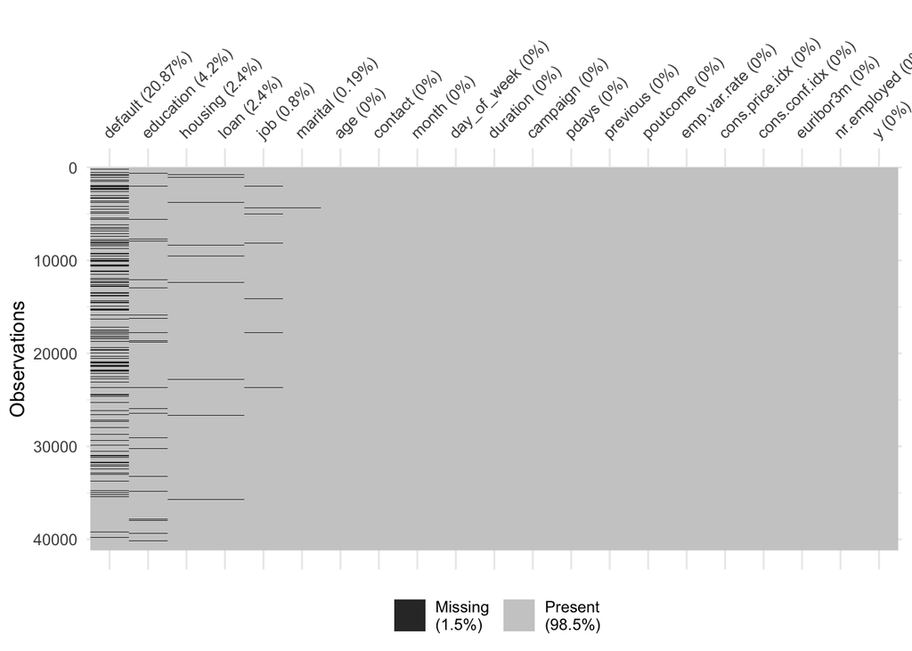

```r
vis_miss(data, sort_miss = TRUE)
```

There are a few missing values associated with `job`, `marital`, `education`, `housing`, `loan`. But there are 20.87% missing values for `default`.

We use the `mice` package to impute the missing values.

```r
#imputed_data = mice(data, maxit = 1, method = 'pmm', seed = 6)
#data = complete(imputed_data)

# save the data
#write.csv(data, "cleaned_data_additional_full.csv")
```

```r
# Now we can read the data directly
data = read.csv("cleaned_data_additional_full.csv")[,-1]
```

## Balance of Dataset

In classification problem, the balance of dataset refers to the ratio of the number of output classes. Usually, 10:1 will be acceptable.

```r
table(data$y)
```

```
##
##    no   yes
## 36548  4640
```

```r
cat("The ratio of balance: ", table(data$y)['no']/table(data$y)['yes'])
```

```
## The ratio of balance:  7.876724
```

The dataset is balanced as the ratio is approximately 8:1.

## Variable Exploration

### age

How is `age` distributed and how is it related to `y`?

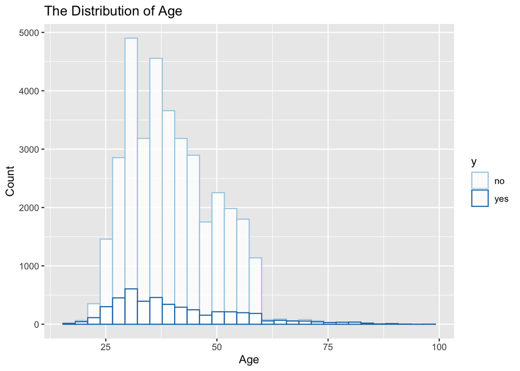

```r
# distribution of variable age
ggplot(data, aes(x = age, color = y)) +
  geom_histogram(fill = "white", alpha=0.8, position="identity") +
  ggtitle("The Distribution of Age") +
  xlab("Age") +
  ylab("Count") +
  scale_color_brewer(palette = "Paired")
```

We can see that most of the potential subscribers are middle-aged. It also seems that even though most potential subscribers are middle-aged, the proportion of these people who actually subscribed are comparably low. The campaign works well in young and old people, but proportionally we do not have a lot of such customers.

### Job

How is `job` related to `y`?

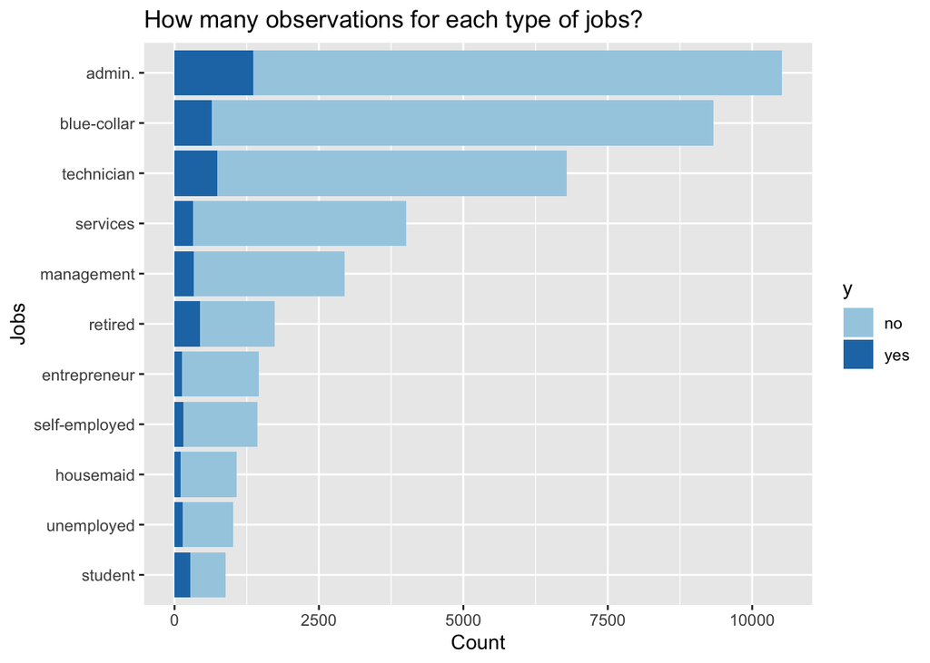

```r
data %>%
  group_by(y) %>%
  count(job) %>%
  ungroup() %>%
#ggplot(data, aes(fill=y, y=..count.., x=job)) +
  #geom_bar(position="stack", stat="count") +
  ggplot(aes(x=reorder(job,n),y=n,fill=y))+
  geom_bar(stat="identity")+
  ggtitle("How many observations for each type of jobs?") +
  xlab("Jobs") +
  ylab("Count") +
  coord_flip() +
  scale_fill_brewer(palette = "Paired")
```

Based on the plot, the proportion of retired and student subscribers are optimal. Most of people in our dataset are admin., blue-collar and technician, however, the proportion of subscribers is just a few.

### marital status

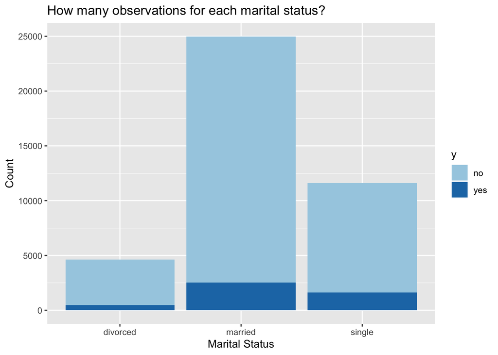

```r
ggplot(data, aes(fill=y, y=..count.., x=marital)) +
  geom_bar(position="stack", stat="count") +
  ggtitle("How many observations for each marital status?") +
  xlab("Marital Status") +
  ylab("Count") +
  scale_fill_brewer(palette = "Paired")
```

There are many married people but just a few of them are subscribers.

### education

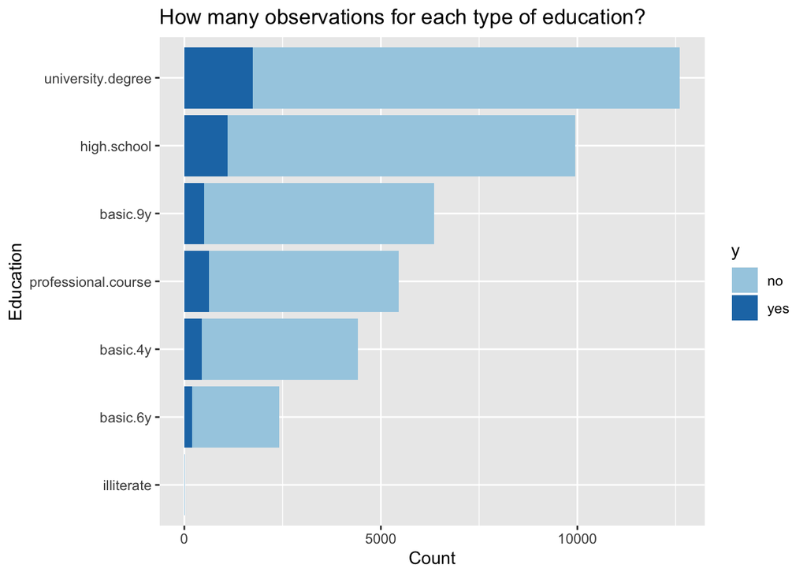

```r
data %>%
  group_by(y) %>%
  count(education) %>%
  ungroup() %>%
  ggplot(aes(x=reorder(education,n),y=n,fill=y))+
    geom_bar(stat="identity") +
    ggtitle("How many observations for each type of education?") +
    xlab("Education") +
    ylab("Count") +
    coord_flip() +
    scale_fill_brewer(palette = "Paired")
```

```r
#ggplot(data, aes(fill=y, y=..count.., x=education)) +
#    geom_bar(position="stack", stat="count") +
```

Most people are educated, and the majority obtained university degree. It is hard to say that higher-educated people are more likely to subscribe.

### default

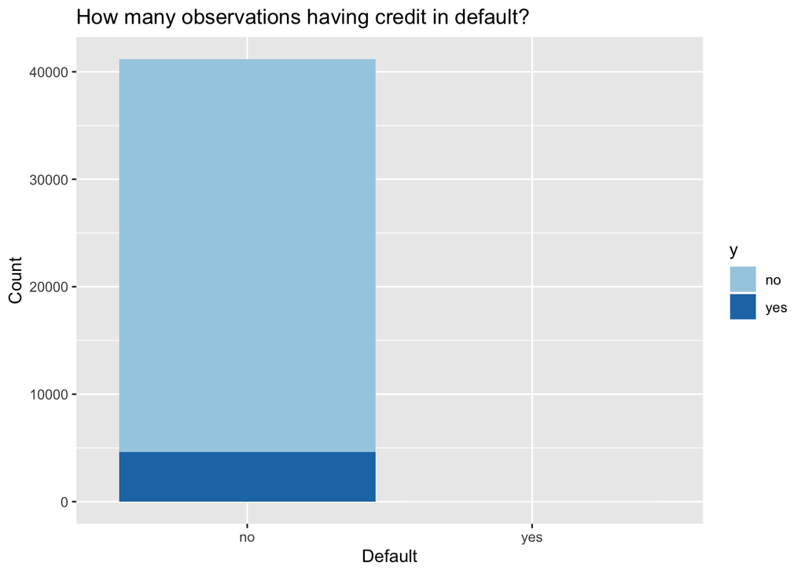

```r
data %>%
  group_by(y) %>%
  count(default) %>%
  ungroup() %>%
  #ggplot(data, aes(fill=y, y=..count.., x=default)) +
  #  geom_bar(position="stack", stat="count")
  ggplot(aes(x=reorder(default,-n),y=n,fill=y))+
    geom_bar(stat="identity") +
    ggtitle("How many observations having credit in default?") +
    xlab("Default") +
    ylab("Count") +
    scale_fill_brewer(palette = "Paired")
```

Looks like only few observations have `default` = yes. We look at these observations.

```r
# observations where default = yes
data$y[data$default == "yes"]
```

```
## [1] no  yes no  no  no  no  no  no
## Levels: no yes
```

Most of the observations did not subscribe. But we cannot say there is any pattern, since this is the case within the whole population.

### contact

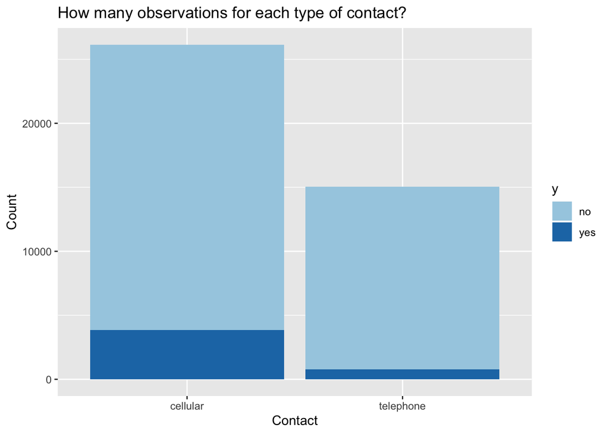

```r
#ggplot(data, aes(fill=y, y=..count.., x=contact)) +
#    geom_bar(position="stack", stat="count")
data %>%
  group_by(y) %>%
  count(contact) %>%
  ungroup() %>%
  ggplot(aes(x=reorder(contact,-n),y=n,fill=y))+
    geom_bar(stat="identity") +
    ggtitle("How many observations for each type of contact?") +
    xlab("Contact") +
    ylab("Count") +
    scale_fill_brewer(palette = "Paired")
```

The plot shows that eople who are contacted by celluar phone are more likely to subscribe.

### housing

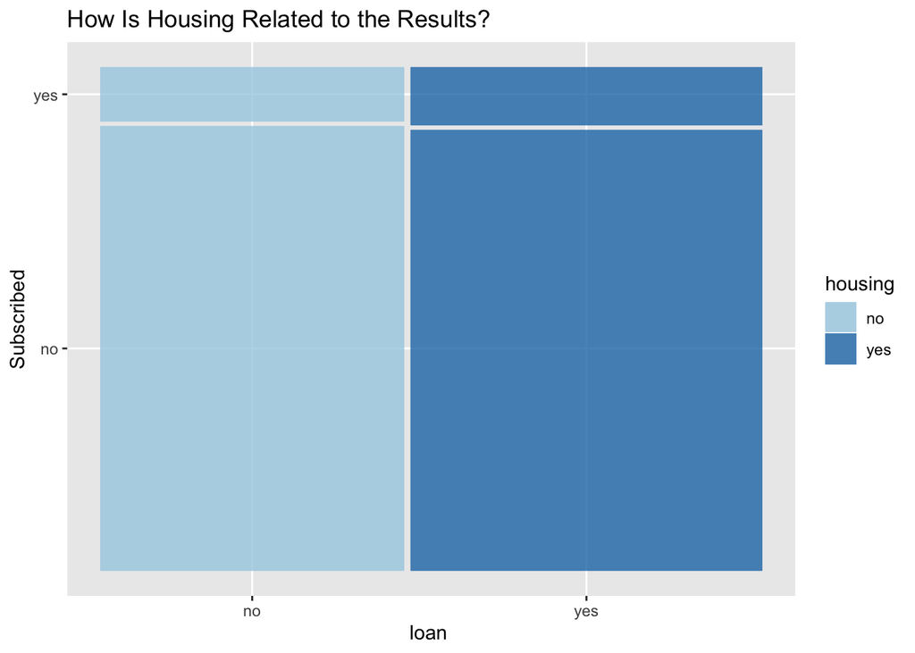

```r
ggplot(data = data) +
   geom_mosaic(aes(x = product(y, housing), fill = housing), na.rm=TRUE) +
  labs(x = "loan ", y = 'Subscribed', title='How Is Housing Related to the Results?') +
  scale_fill_brewer(palette = "Paired")
```

The `housing` variable has only little affect on the results.

### loan

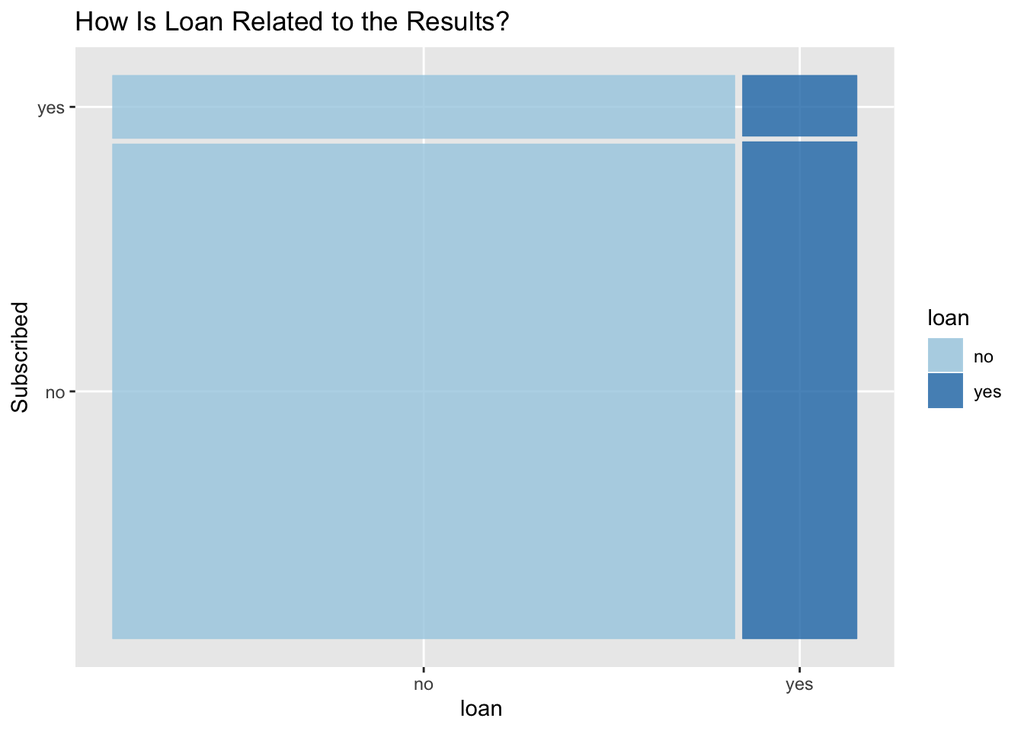

```r
#ggplot(data, aes(fill=y, y=..count.., x=loan)) +
#    geom_bar(position="stack", stat="count")
ggplot(data = data) +
   geom_mosaic(aes(x = product(y, loan), fill = loan), na.rm=TRUE) +
  labs(x = "loan ", y = 'Subscribed', title='How Is Loan Related to the Results?') +
  scale_fill_brewer(palette = "Paired")
```

The `loan` variable has only little affect on the results.

### month

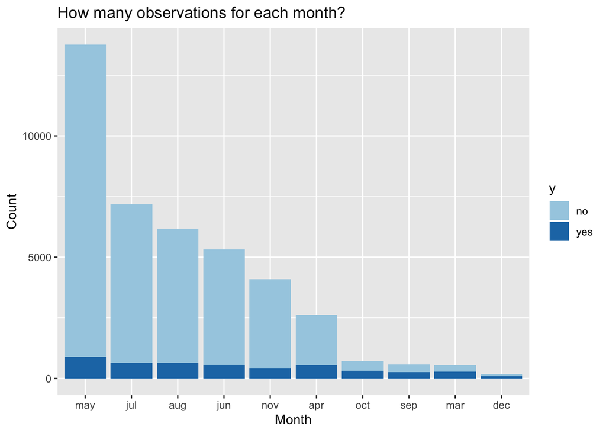

```r
#ggplot(data, aes(fill=y, y=..count.., x=month)) +
#    geom_bar(position="stack", stat="count")
data %>%
  group_by(y) %>%
  count(month) %>%
  ggplot(aes(x=reorder(month,-n), y=n, fill=y)) +
    geom_bar(stat="identity") +
    ggtitle("How many observations for each month?") +
    xlab("Month") +
    ylab("Count") +
    scale_fill_brewer(palette = "Paired")
```

From the plot, we can see that there are many more observation in May. However, the proportion of people subscribed are not optimal. Also, there are not many observations on December, March, October, September, but the proportion of subscriptions is pretty high.

### day_of_week

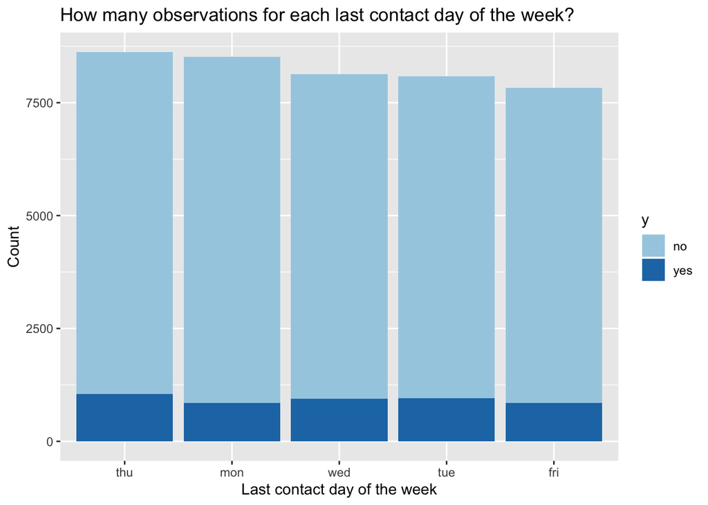

```r
#ggplot(data, aes(fill=y, y=..count.., x=day_of_week)) +
#    geom_bar(position="stack", stat="count")
data %>%
  group_by(y) %>%
  count(day_of_week) %>%
  ggplot(aes(x=reorder(day_of_week,-n), y=n, fill=y)) +
    geom_bar(stat="identity") +
    ggtitle("How many observations for each last contact day of the week?") +
    xlab("Last contact day of the week") +
    ylab("Count") +
    scale_fill_brewer(palette = "Paired")
```

There aren’t siginificant differences in `day_of_week`.

### duration

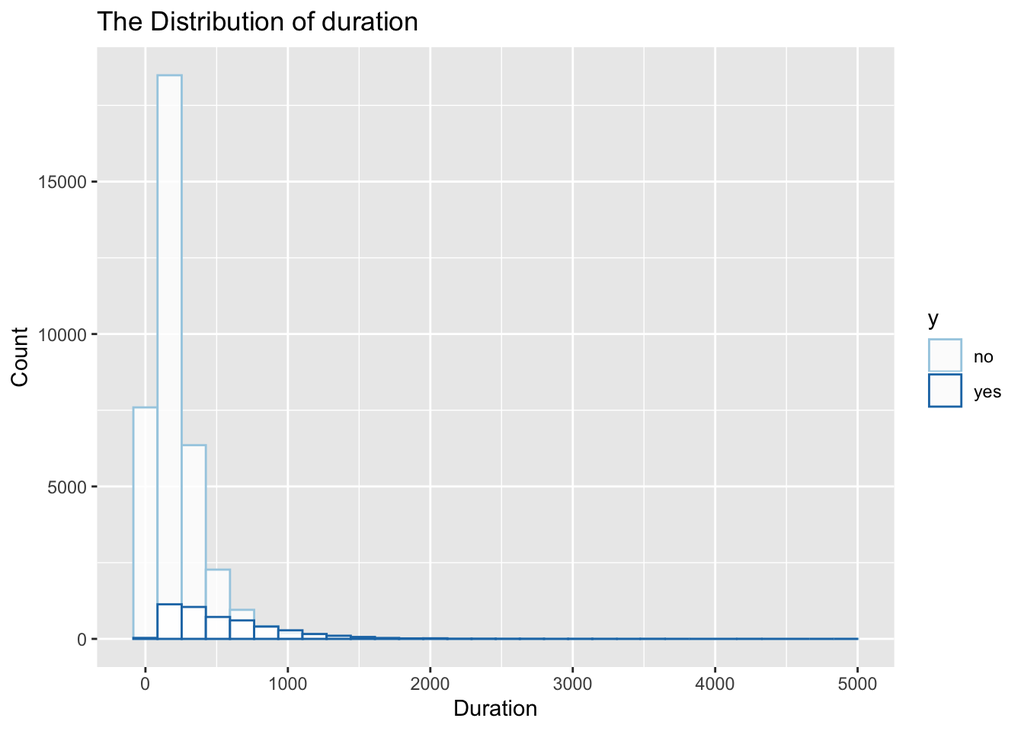

```r
#ggplot(data, aes(fill=y, y=..count.., x=duration)) +
#    geom_histogram()
ggplot(data, aes(x = duration, color = y)) +
  geom_histogram(fill = "white", alpha=0.8, position="identity") +
  ggtitle("The Distribution of duration") +
  xlab("Duration") +
  ylab("Count") +
  scale_color_brewer(palette = "Paired")
```

When duration is near 0, almost no one subscribed. However, as duration increases, it seems that the proportion of people who subscribed increases.

### campaign

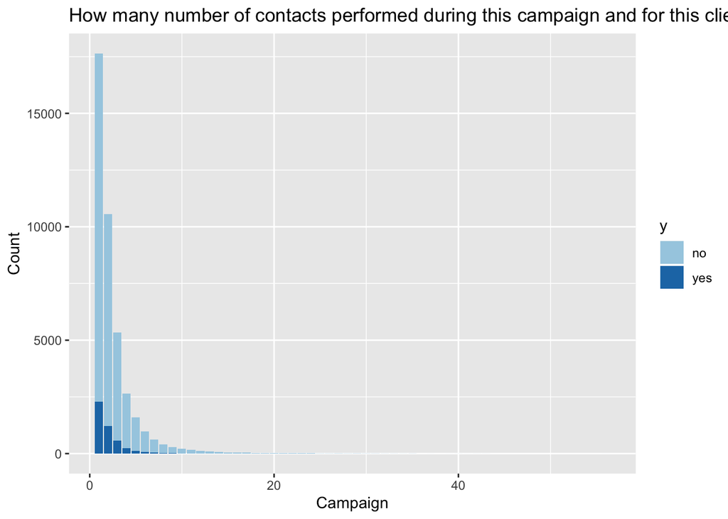

```r
ggplot(data, aes(fill=y, y=..count.., x=campaign)) +
  geom_bar(position="stack", stat="count") +
  scale_fill_brewer(palette = "Paired") +
  ggtitle("How many number of contacts performed during this campaign and for this client?") +
  xlab("Campaign") +
  ylab("Count")
```

### pdays

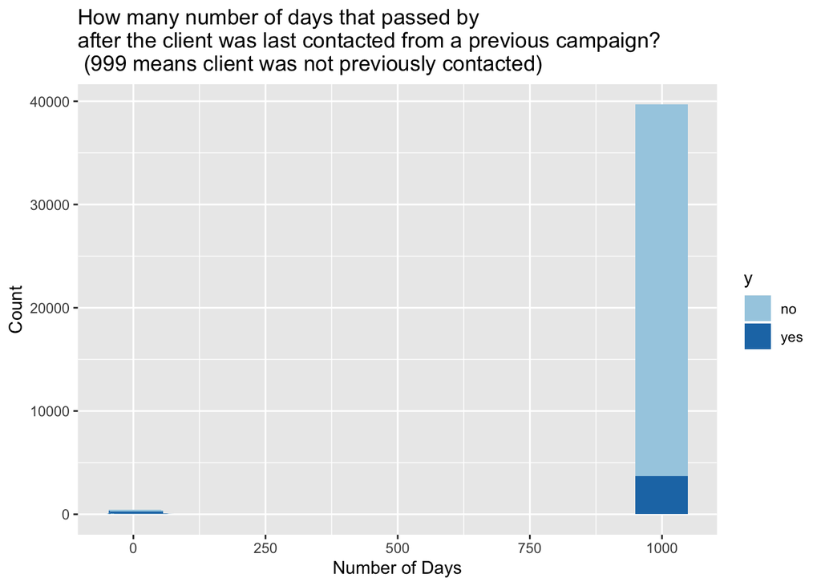

```r
# may be change level 999?
ggplot(data, aes(fill=y, y=..count.., x=pdays)) +
  geom_bar(width = 100, position="stack", stat="count") +
  scale_fill_brewer(palette = "Paired") +
  ggtitle("How many number of days that passed by \nafter the client was last contacted from a previous campaign? \n (999 means client was not previously contacted)") +
  xlab("Number of Days") +
  ylab("Count")
```

Most of clients not previouly being contacted. Therefore, we plot again except the value of 999.

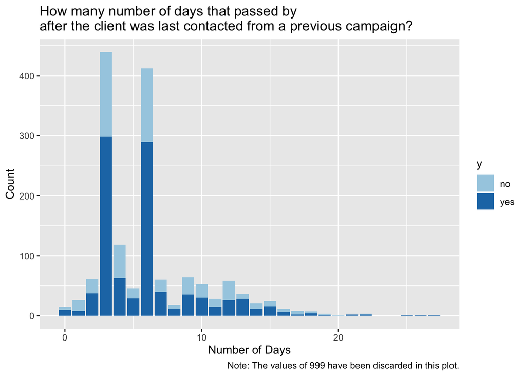

```r
data %>% filter(pdays!=999) %>%
  ggplot(aes(fill=y, y=..count.., x=pdays)) +
    geom_bar(position="stack", stat="count") +
    scale_fill_brewer(palette = "Paired") +
    ggtitle("How many number of days that passed by \nafter the client was last contacted from a previous campaign?") +
    xlab("Number of Days") +
    ylab("Count") +
    labs(caption="Note: The values of 999 have been discarded in this plot.")
```

Most of clients who were previously contacted were contacted less than 10 days ago.

### previous

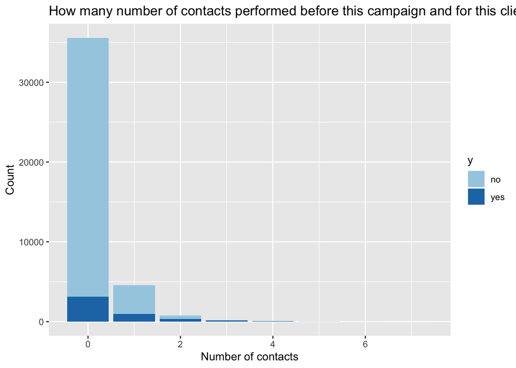

```r
ggplot(data, aes(fill=y, y=..count.., x=previous)) +
    geom_bar(position="stack", stat="count") +
    scale_fill_brewer(palette = "Paired") +
    ggtitle("How many number of contacts performed before this campaign and for this client?") +
    xlab("Number of contacts") +
    ylab("Count")
```

### poutcome

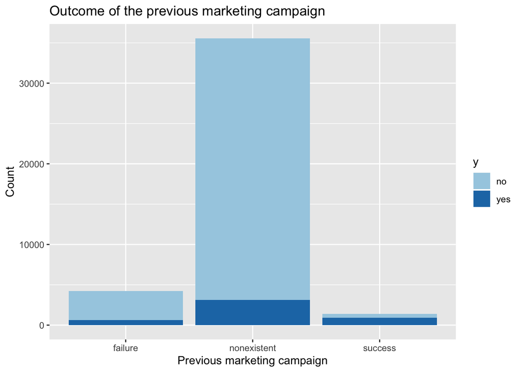

```r
ggplot(data, aes(fill=y, y=..count.., x=poutcome)) +
    geom_bar(position="stack", stat="count") +
    scale_fill_brewer(palette = "Paired") +
    ggtitle("Outcome of the previous marketing campaign") +
    xlab("Previous marketing campaign") +
    ylab("Count")
```

From the plot, we found that if previous marketing campagin succeeded, people are more likely to subscribe.

### emp.var.rate

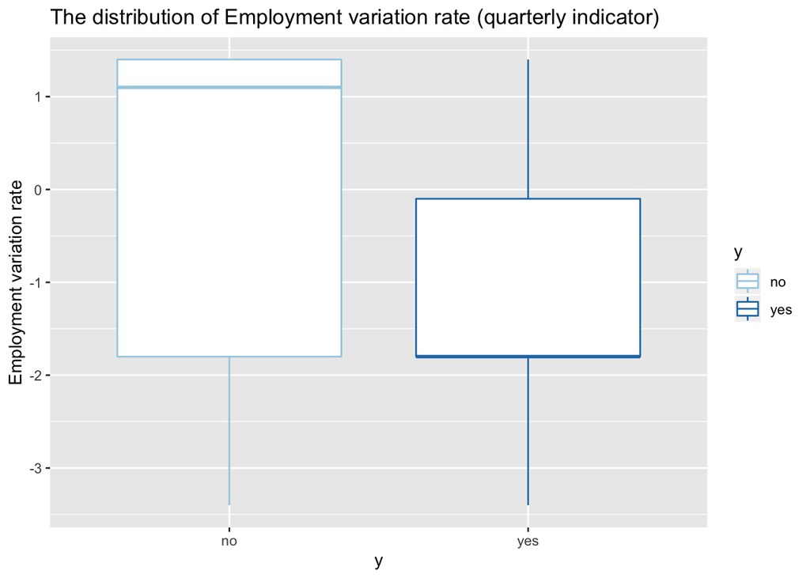

```r
#ggplot(data, aes(fill=y, y=..count.., x=emp.var.rate)) +
#  geom_histogram(bins=6, position='stack') +
ggplot(data, aes(x=y,y=emp.var.rate,color=y)) +
  geom_boxplot() +
  scale_color_brewer(palette = "Paired") +
  ggtitle("The distribution of Employment variation rate (quarterly indicator)") +
  ylab("Employment variation rate")
```

### cons.price.idx

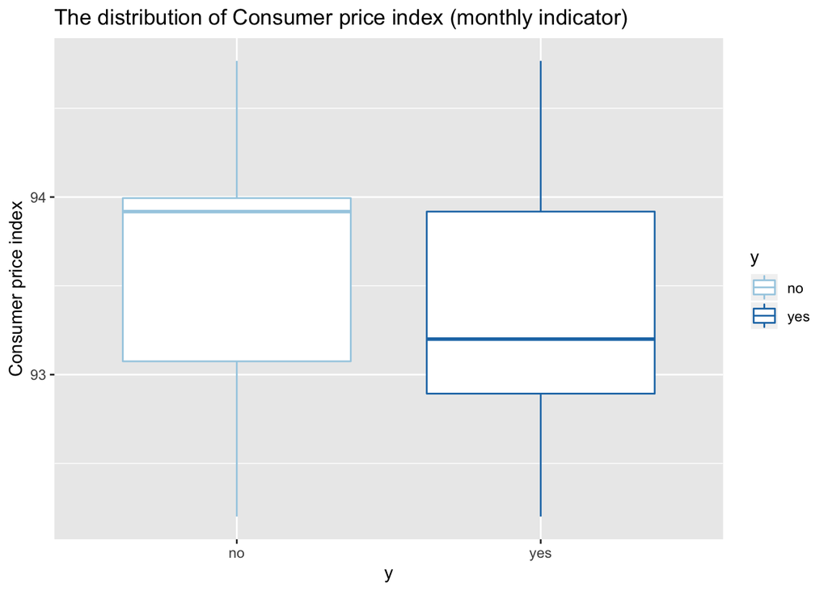

```r
#ggplot(data, aes(fill=y, y=..count.., x=cons.price.idx)) +
#    geom_histogram(bins=5)
ggplot(data, aes(x=y,y=cons.price.idx,color=y)) +
  geom_boxplot() +
  scale_color_brewer(palette = "Paired") +
  ggtitle("The distribution of Consumer price index (monthly indicator)") +
  ylab("Consumer price index")
```

### cons.conf.idx

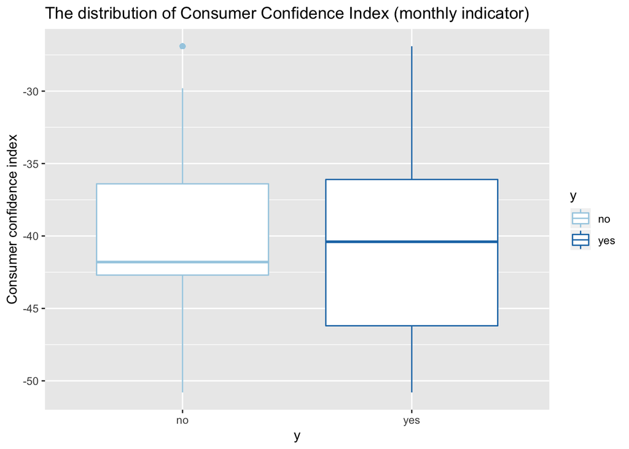

```r
ggplot(data, aes(x=y,y=cons.conf.idx, color=y)) +
  geom_boxplot() +
  scale_color_brewer(palette = "Paired") +
  ggtitle("The distribution of Consumer Confidence Index (monthly indicator)") +
  ylab("Consumer confidence index")
```

### euribor3m

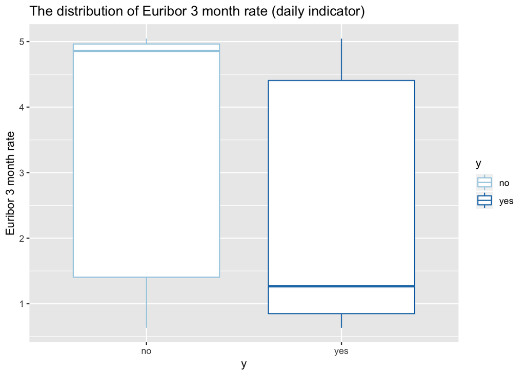

```r
ggplot(data, aes(x=y,y=euribor3m, color=y)) +
  geom_boxplot() +
  scale_color_brewer(palette = "Paired") +
  ggtitle("The distribution of Euribor 3 month rate (daily indicator)") +
  ylab("Euribor 3 month rate")
```

### nr.employed

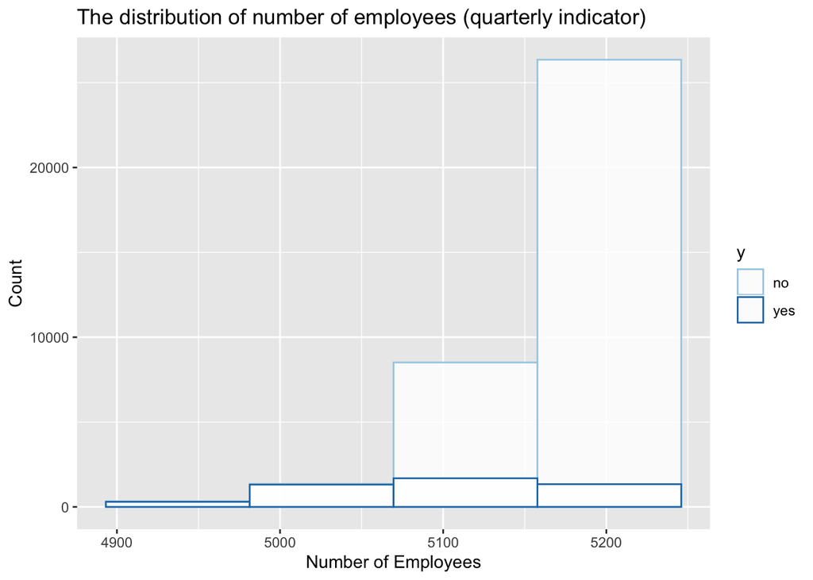

```r
#ggplot(data, aes(fill=y, y=..count.., x=nr.employed)) +
#    geom_histogram(bins=4)

# distribution of variable age
ggplot(data, aes(x = nr.employed, color = y)) +
  geom_histogram(fill="white",alpha=0.8, position="identity", bins=4) +
  ggtitle("The distribution of number of employees (quarterly indicator)") +
  xlab("Number of Employees") +
  ylab("Count") +
  scale_color_brewer(palette = "Paired")
```

# Feature Engineering

## Correlation

We check the correlations of the variables.

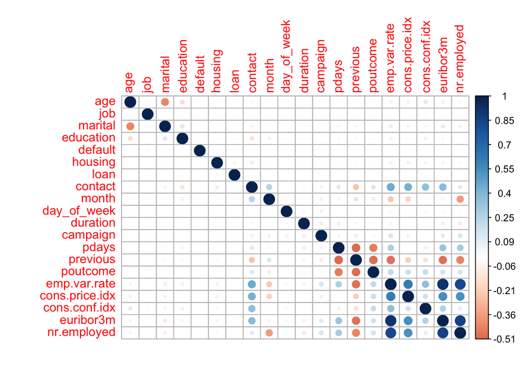

```r
X = data %>%
  select(-y)

# change into integer
for(i in 1:ncol(X)){
  X[,i] <- as.integer(X[,i])
}


corr_mat=cor(X,method="s")
corrplot(corr_mat, is.corr = FALSE, win.asp = .7, method = "circle")
```

We denote that `emp.var.rate`, `euribor3m` and `nr.employed` are highly correlated to each other.

We look at the description of the three variables:

1. emp.var.rate: employment variation rate - quarterly indicator (numeric)
2. euribor3m: euribor 3 month rate - daily indicator (numeric)
3. nr.employed: number of employees - quarterly indicator (numeric)

We may consider remove `emp.var.rate` and `euribor3m` while modelling.

Also, we remove the `duration` variable based on the dataset author’s note: “this attribute highly affects the output target (e.g., if duration=0 then y=‘no’). Yet, the duration is not known before a call is performed. Also, after the end of the call y is obviously known. Thus, this input should only be included for benchmark purposes and should be discarded if the intention is to have a realistic predictive model.”

```r
data = data %>%
  select(-c(emp.var.rate, euribor3m, duration))
```

# Modeling

```r
# train-test split
set.seed(2383)
size = floor(0.75 * nrow(data))
train_index <- sample(seq_len(nrow(data)), size = size)
train = data[train_index,]
train_X = train %>% select(-y)
test = data[-train_index,]
test_X = test %>% select(-y)
```

## Logistic Regression

We first fit a logistic regression model since the response variable is binary.

```r
train_logit <- train[,]
test_logit <- test[,]
levels(train_logit$y) <- c(0,1)
levels(test_logit$y) <- c(0,1)
```

```r
logit_mod <- glm(y ~ ., data = train, family = binomial)
```

Since there are much less observations who subscribed to a term deposit, we define a threshold that if the predicted value is greater than 0.5, we treat it as subscribed.

```r
logit_pred = logit_mod %>% predict(test_X , type = "response")
logit_pred = ifelse(logit_pred > 0.5, 1, 0)
logit_pred_acc = mean(logit_pred == test_logit$y)
cat("Prediction Accuracy Rate: ",logit_pred_acc)
```

```
## Prediction Accuracy Rate:  0.9016218
```

The accuracy achieved is 0.9016218 To further invest on this model, we look at the confusion matrix.

```r
table(test_logit$y, logit_pred > 0.5)
```

```
##
##     FALSE TRUE
##   0  8988  128
##   1   885  296
```

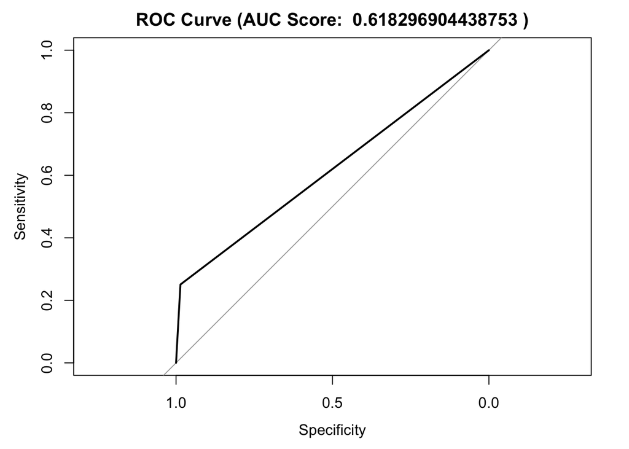

```r
logit_roc <- roc(test_logit$y,logit_pred,direction="<")
logit_auc <- auc(logit_roc)
plot(logit_roc, main=paste("ROC Curve (AUC Score: ",logit_auc,")"))
```

```r
logit_pred = predict(logit_mod, test_X, type = "response")
logit_pred = ifelse(logit_pred > 0.2, 1, 0)
logit_pred_acc = mean(logit_pred == test_logit$y)
cat("Prediction Accuracy Rate: ",logit_pred_acc)
```

```
## Prediction Accuracy Rate:  0.8679227
```

```r
table(test_logit$y, logit_pred > 0.2)
```

```
##
##     FALSE TRUE
##   0  8261  855
##   1   505  676
```

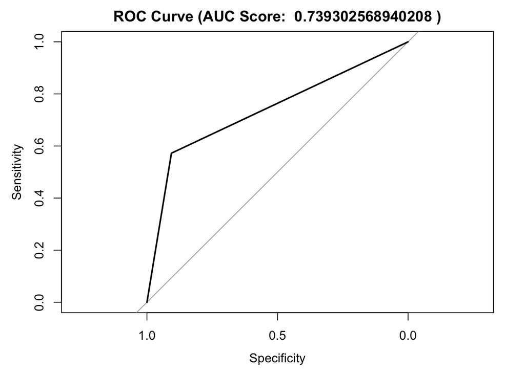

```r
logit_roc <- roc(test_logit$y,logit_pred,direction="<")
logit_auc <- auc(logit_roc)
plot(logit_roc, main=paste("ROC Curve (AUC Score: ",logit_auc,")"))
```

The model works well in identifying potential customers. We will try more advanced models next.

## Naive Bayes

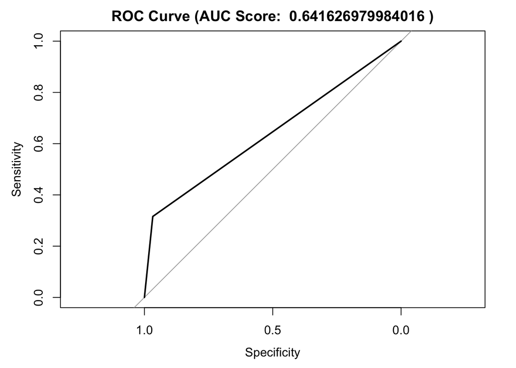

```r
nb_roc <- roc(as.integer(test$y),as.integer(nb_pred),direction="<")
nb_auc <- auc(nb_roc)
plot(nb_roc, main=paste("ROC Curve (AUC Score: ",nb_auc,")"))
```

## SVM

It takes too long to train.

```
svm_linear_control <- trainControl(
  method = "cv",
  number = 5,
  verbose = FALSE
)

svm_linear_grid <- expand.grid(
  C = c(0.1, 1, 10)
)

svm_linear_model <- train(
  y~.,
  data = train,
  method = "svmLinear",
  trControl = svm_linear_control,
  tuneGrid = svm_linear_grid,
  preProc = c("scale","center"),
  verbose = FALSE
)
svm_linear_model$bestTune
```

```
# radiao kernel
```

## Random Forest

```r
rf_grid = expand.grid(mtry = 1 : 8)

## out of bag
oob = trainControl(method = "oob")
rf_oob_tune = train(
  y ~ .,
  data = train,
  method = "rf",
  trControl = oob,
  verbose = FALSE,
  tuneGrid = rf_grid
  )

rf_oob_tune$bestTune
```

```
##   mtry
## 2    2
```

```r
varImp(rf_oob_tune, scale = FALSE)
```

```
## rf variable importance
##
##   only 20 most important variables shown (out of 44)
##
##                            Overall
## nr.employed                 272.92
## pdays                       152.92
## cons.conf.idx               140.91
## cons.price.idx              120.28
## poutcomesuccess             118.39
## age                          86.22
## previous                     59.97
## poutcomenonexistent          38.12
## contacttelephone             36.66
## monthoct                     35.12
## monthmar                     33.21
## campaign                     31.21
## monthsep                     19.82
## monthmay                     18.48
## jobstudent                   13.61
## monthjun                     12.81
## jobretired                   12.14
## educationuniversity.degree   12.08
## day_of_weekmon               11.91
## housingyes                   11.53
```

```r
rf_oob_pred = predict(rf_oob_tune, test)
rf_oob_pred_acc = sum(rf_oob_pred == test$y) / length(test$y)
cat("Prediction Accuracy Rate: ",rf_oob_pred_acc)
```

```
## Prediction Accuracy Rate:  0.8988055
```

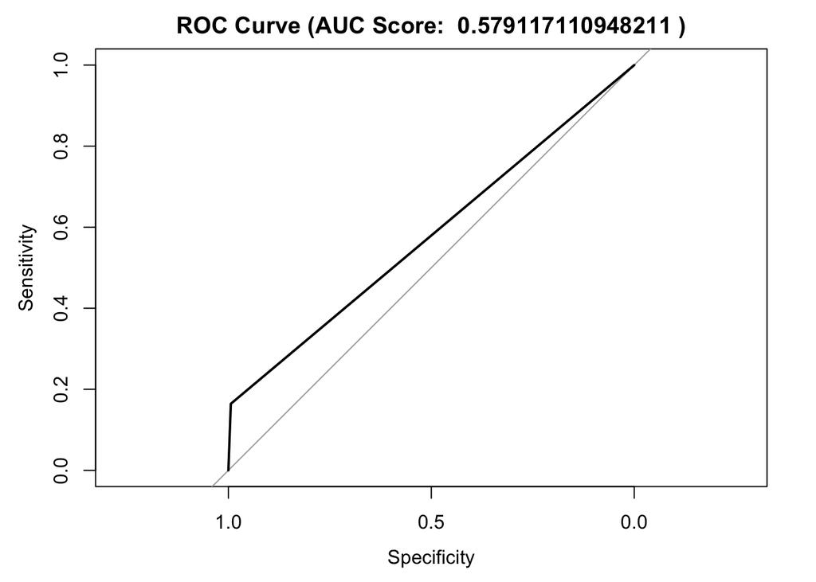

```r
rf_roc <- roc(as.integer(test$y),as.integer(rf_oob_pred),direction="<")
rf_auc <- auc(rf_roc)
plot(rf_roc, main=paste("ROC Curve (AUC Score: ",rf_auc,")"))
```

From the AUC-ROC curve, the random forest model is good but is not as good as logistic regression.

## Gradient Boosting

```r
gb_control <- trainControl(
   method = "cv",
   number = 5
)

gb_grid <-  expand.grid(interaction.depth = c(3, 5, 9),
                        n.trees = 500,
                        shrinkage = 0.1,
                        n.minobsinnode = 20)

gb_model <- train(y ~ ., data = train,
                 method = "gbm",
                 trControl = gb_control,
                 verbose = FALSE,
                 tuneGrid = gb_grid)
```

```r
gb_pred <- predict(gb_model, test)
gb_pred_acc <- sum(gb_pred == test$y) / length(test$y)
cat("Prediction Accuracy Rate: ",gb_pred_acc)
```

```
## Prediction Accuracy Rate:  0.902593
```

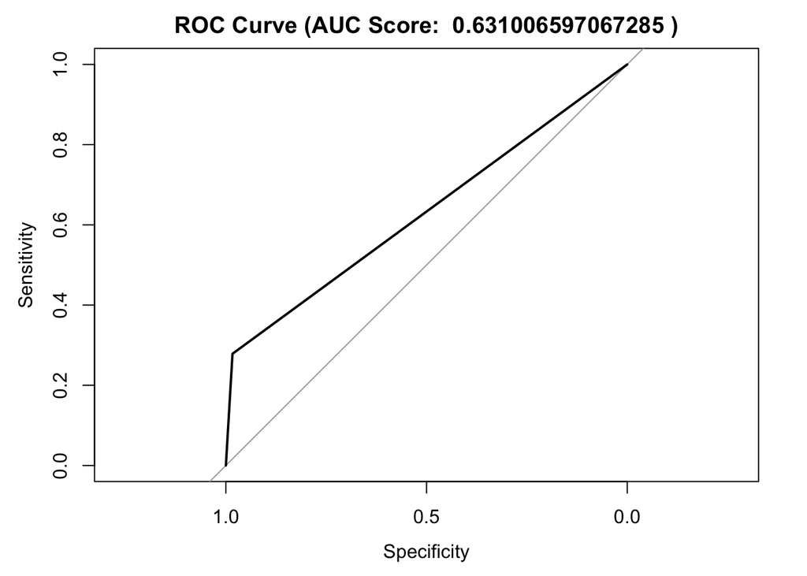

```r
gb_roc <- roc(as.integer(test$y),as.integer(gb_pred),direction="<")
gb_auc <- auc(gb_roc)
plot(gb_roc, main=paste("ROC Curve (AUC Score: ",gb_auc,")"))
```

The accuracy rate is 0.902593 and the auc score is 0.6310066.

## XGBoost

```r
xgb_control <- trainControl(
  method = "cv",
  number = 5,
  search = "random",
  savePredictions = TRUE,
  classProbs = TRUE
)

xgb_grid <- expand.grid(
  eta=0.1,
  gamma=1,
  max_depth=6,
  colsample_bytree=0.9,
  nrounds=10,
  min_child_weight=10,
  subsample = 0.9
  )

xgb_model <- train(
  y ~.,
  data = train,
  method = "xgbTree",
  metric = "Accuracy",
  nthread = 2,
  verbosity = 0,
  tuneGrid = xgb_grid,
  trControl = xgb_control
)
xgb_model$bestTune
```

```
##   nrounds max_depth eta gamma colsample_bytree min_child_weight subsample
## 1      10         6 0.1     1              0.9               10       0.9
```

```r
xgb_pred <- predict(xgb_model, test)
xgb_pred_acc <- sum(xgb_pred == test$y) / length(test$y)
cat("Prediction Accuracy Rate: ",xgb_pred_acc)
```

```
## Prediction Accuracy Rate:  0.9015247
```

```r
varImp(xgb_model,scale = FALSE)
```

```
## xgbTree variable importance
##
##   only 20 most important variables shown (out of 44)
##
##                             Overall
## nr.employed                0.530566
## cons.conf.idx              0.101494
## pdays                      0.100889
## poutcomesuccess            0.067106
## cons.price.idx             0.040289
## monthoct                   0.023887
## age                        0.022168
## contacttelephone           0.021548
## day_of_weekmon             0.013226
## monthmar                   0.011534
## monthjun                   0.010701
## campaign                   0.009150
## previous                   0.006668
## poutcomenonexistent        0.006489
## day_of_weekthu             0.005906
## monthmay                   0.005138
## educationuniversity.degree 0.003989
## monthsep                   0.002812
## jobblue-collar             0.002215
## maritalmarried             0.002018
```

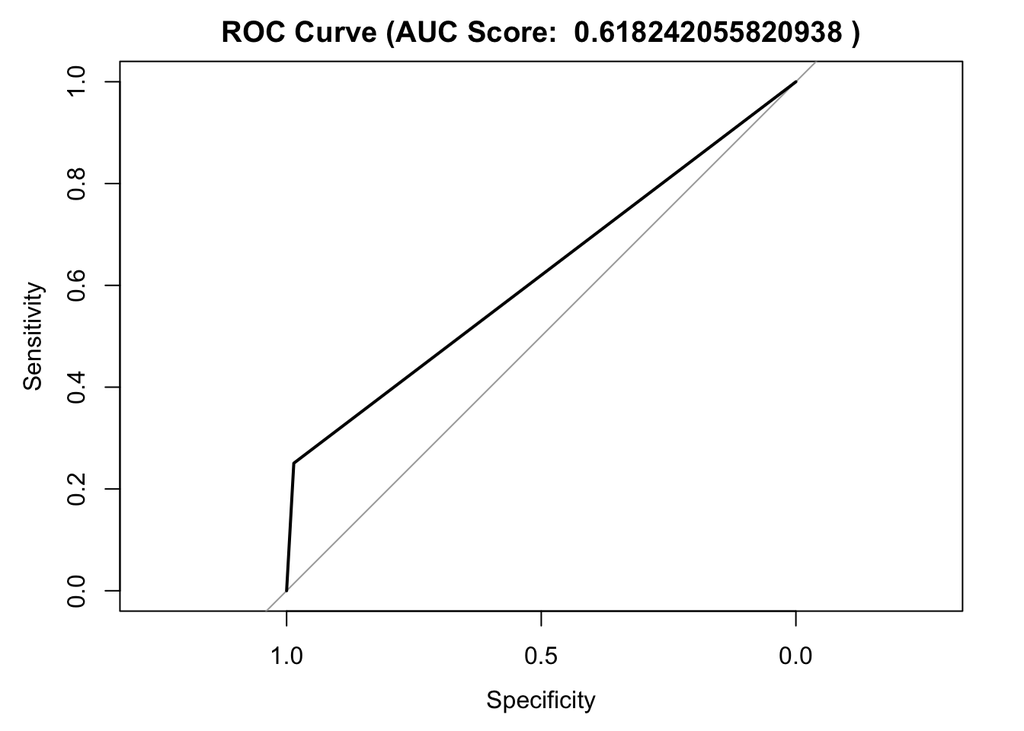

```r
xgb_roc <- roc(as.integer(test$y),as.integer(xgb_pred),direction="<")
xgb_auc <- auc(xgb_roc)
plot(xgb_roc, main=paste("ROC Curve (AUC Score: ",xgb_auc,")"))
```

The accuracy rate is 0.9015247 and the auc score is 0.6182421.

## CatBoost

We notice that there are many categorical variables, and also some discrete variables which can also be treaded as categorical. CatBoost is a powerful model which performance on dataset with many categorical variables in that it has various methods to handle categorical variables. However, since some of categorical variables seem to be high cardinal, the result may not be as good as we expect.

```r
# extract features and labels for modeling
features <- train %>% select(-y)
labels <- train$y
```

```r
cat_control <- trainControl(
  method = "cv",
  number = 5,
  search = "random",
  classProbs = TRUE
)
cat_grid <- expand.grid(
  depth = c(4,6,8),
  learning_rate = c(0.01, 0.1, 1),
  l2_leaf_reg = c(0.1,1,2,4,6),
  rsm = 0.95,
  border_count = 64,
  iterations = 10

)
cat_model <- train(
  x = features,
  y = labels,
  method = catboost.caret,
  metric = "Accuracy",
  bootstrap_type = 'Bayesian',
  maximize = TRUE,
  logging_level='Silent',
  tuneGrid = cat_grid,
  trControl = cat_control
)
cat_model$bestTune
```

```
##    depth learning_rate iterations l2_leaf_reg  rsm border_count
## 29     6             1         10           4 0.95           64
```

```r
cat_pred <- predict(cat_model, test)
cat_pred_acc <- sum(cat_pred == test$y) / length(test$y)
cat("Prediction Accuracy Rate: ",cat_pred_acc)
```

```
## Prediction Accuracy Rate:  0.8991939
```

```r
varImp(cat_model,scale = FALSE)
```

```
## custom variable importance
##
##                  Overall
## nr.employed    54.231523
## cons.conf.idx  13.643267
## pdays           7.484781
## month           7.130107
## contact         6.222859
## age             5.498299
## previous        2.039418
## campaign        1.633886
## poutcome        1.259504
## housing         0.423753
## marital         0.337672
## cons.price.idx  0.092247
## default         0.002685
## education       0.000000
## day_of_week     0.000000
## loan            0.000000
## job             0.000000
```

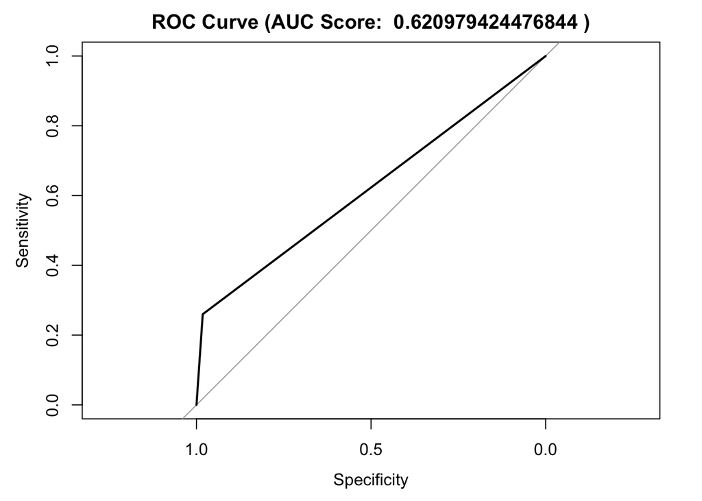

```r
cat_roc <- roc(as.integer(test$y),as.integer(cat_pred),direction="<")
cat_auc <- auc(cat_roc)
plot(cat_roc, main=paste("ROC Curve (AUC Score: ",cat_auc,")"))
```

The prediction accuracy rate on our test dataset is **0.8991939**, and the AUC score is 0.6209794. Our best parameters selected from the grid search is also shown above. From our best model, `nr.employed` is the most important variable.